# Web-scraping eldiario.es articles

Trabajo Fin de Master

Isabel Molero López

# 1.Introduction

For my master’s thesis I have to extract the text and date of the news related to artificial intelligence published by two Spanish newspapers: eldiario.es and El Mundo. In this rmd I explain how to perform the web scraping to extract this information from eldiario.es and save it in a csv.

# Load libraries

First I am going to load the libraries I will use:

```r
# General libraries:
library(tidyverse)

# Web scrapping libraries:
library(RSelenium)
library(xml2)
library(scrapex)
library(rvest)
library(httr)

# Plots:
library(ggplot2)
```

```r
rm(list = ls()) # clean the environment
```

# Web scraping

## The original link: Google News

To extract the news from both digital newspapers I have decided to use Google’s news search engine “Google News”. This allows me to recycle the code and use a similar one for both newspapers. Otherwise, using the search engines of each digital newspaper I would have to create a specific code for each one, besides the search criteria would be different.

The search query I have introduced in Google News to search for articles containing the words “artificial intelligence” in the webpage “eldiario.es” and in the webpage “elmundo.es” are the following:

- eldiario.es: “artificial intelligence” site:eldiario.es after: 2023-04-03 before: 2023-05-03
- elmundo.es: “artificial intelligence” site:elmundo.es after: 2023-04-03 before: 2023-05-03

In addition, with the filters provided by Google I set the desired time interval. The links of the web page that I have to webscrap to, in turn, obtain the links of each news item are as follows:

- eldiario.es: “https://www.google.com/search?q=%22inteligencia+artificial%22+site:eldiario.es+after:2023-04-03+before:2023-05-03&lr=lang_es&tbs=lr:lang_1es&tbm=nws”
- elmundo.es: “https://www.google.com/search?q=%22inteligencia+artificial%22+site:elmundo.es+after:2023-04-03+before:2023-05-03&lr=lang_es&tbs=lr:lang_1es&tbm=nws”

## Set user-agent

To identify the person who is scraping the website I have to set my user-agent. This string contains information about my computer/browser and my name/email to make identification easier:

```r
set_config(
  user_agent("Mozilla/5.0 (Windows NT 10.0; Win64; x64; rv:102.0) Gecko/20100101 Firefox/102.0; Isabel Molero / sisamolero@gmail.com")
)
```

## Find the xpath for each article

Next I will look for the xpath where each news item is located in the link. Keep in mind that on the Google News web page the hyperlinks to each news item are spread over several pages. On each page there are 10 articles, and at the bottom you can click on a “next” button or directly click on the page number you want to access.

Here I show a screenshot of how the news looks on the web:

[figure not shown]

```r
knitr::include_graphics("google_news_siguiente.jpg")
```

### Read the html

To find the xpath where each news item is located I will first save the link in an R object and read the html:

```r
# Create the object with both links:

link_eldiario <- "https://www.google.com/search?q=%22inteligencia+artificial%22+site:eldiario.es+after:2023-04-03+before:2023-05-03&lr=lang_es&tbs=lr:lang_1es&tbm=nws"

link_elmundo <- "https://www.google.com/search?q=%22inteligencia+artificial%22+site:elmundo.es+after:2023-04-03+before:2023-05-03&lr=lang_es&tbs=lr:lang_1es&tbm=nws"
```

```r
# Read the html from the Google search "eldiario.es":

html_eldiario <- link_eldiario %>%
  read_html()

html_eldiario
```

```
{html_document}
<html lang="es" dir="ltr">
[1] <head>\n<meta http-equiv="Content-Type" content="text/html; charset=UTF-8">\n<style nonce=" ...
[2] <body>\n<div class="signin"><a href="https://accounts.google.com/ServiceLogin?hl=es&amp;con ...
```

```r
# Read the html from the Google search "elmundo.es":
```

Now in the web page itself I open the “developer tools” option and look for the tags in which the news are found in order to build the XPath.

```r
html_eldiario %>%
  xml_find_all("//a")
```

```
{xml_nodeset (5)}
[1] <a href="https://accounts.google.com/ServiceLogin?hl=es&amp;continue=https://www.google.com ...
[2] <a href="https://policies.google.com/technologies/cookies?hl=es&amp;utm_source=ucb" target= ...
[3] <a href="https://consent.google.com/dl?continue=https://www.google.com/search?q%3D%2522inte ...
[4] <a href="https://policies.google.com/privacy?hl=es&amp;utm_source=ucb">Política de Privacid ...
[5] <a href="https://policies.google.com/terms?hl=es&amp;utm_source=ucb">Términos del Servicio</a>
```

## Open the Docker

Once the Docker is downloaded and installed in our computer, we have to open the control panel of our computer and execute the following lines:

- To pull the image: docker pull selenium/standalone-firefox
- To start the Docker container: docker run -d -p 4445:4444 selenium/standalone-firefox

Before executing the code in the rmd file you need to ensure that the status of your Docker container is “running”.

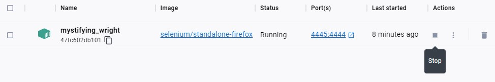

```r
knitr::include_graphics("docker.jpg")
```

## Inizialize the RSelenium Driver

```r
remDr <- RSelenium::remoteDriver(remoteServerAddr = "localhost",
                                 port = 4445L,
                                 browserName = "firefox")
```

## Open the driver

```r
remDr$open()
```

[output not shown]

[output cut: 49 more lines]

[output not shown]

## Navigate to the link with RSelenium

The first thing I do is to navigate to the search link created above. As the first thing that appears is a warning about Cookies, I click on the accept button with the xpath that I have previously located on the web (see image below).

After each step I take screenshots to see that the remote browser is working properly.

```r
# navigate to the link with RSelenium
remDr$navigate(link_eldiario)
remDr$screenshot(display = TRUE)

Sys.sleep(2)

# Accept the cookies to be able to continue browsing the web
remDr$findElement(using = "xpath", value = "//button")$clickElement()
remDr$screenshot(display = TRUE)
```

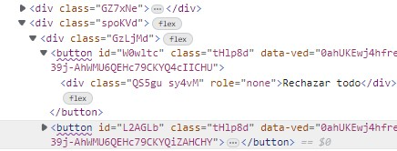

```r
knitr::include_graphics("button_cookies.jpg")
```

## Read the html and find the elements

I search for a word (“riego”) from the title of one of the news items in the html developer tools of the page to see in which tags the links of each one are inserted. Then I can create the XPath that takes me to each one of them.

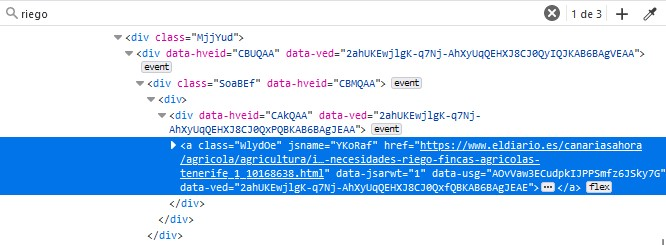

```r
knitr::include_graphics("xpath_link.jpg")
```

```r
# Read the html and find the element where each notice is
page_source <- remDr$getPageSource()[[1]]
Sys.sleep(2)

html <- read_html(page_source)


# List with the links of each article
hrefs <- html %>%
  xml_find_all("//a[@class = 'WlydOe']") %>%
  xml_attr("href")

hrefs
```

```
 [1] "https://www.eldiario.es/canariasahora/agricola/agricultura/inteligencia-artificial-prever-necesidades-riego-fincas-agricolas-tenerife_1_10168638.html"
 [2] "https://cordopolis.eldiario.es/cordoba-hoy/sociedad/inteligencia-artificial-patios_1_10159830.html"
 [3] "https://www.eldiario.es/escolar/inteligencia-artificial-miedo-frankenstein_132_10148712.html"
 [4] "https://www.eldiario.es/tecnologia/inteligencia-artificial-no-simula-voces-personalidades-proyecto-1-000-millones_1_10146066.html"
 [5] "https://www.eldiario.es/tecnologia/falsa-cancion-drake-hecha-inteligencia-artificial-dispara-alarmas-industria-musical_1_10136389.html"
 [6] "https://www.eldiario.es/internacional/inteligencia-artificial-transformando-ejercitos-naturaleza-guerras_1_10095525.html"
 [7] "https://www.eldiario.es/sociedad/porcelana-triturada-anade-calcio-leche-peligro-inteligencia-artificial-genere-informacion-sanitaria_1_10114277.html"
 [8] "https://www.eldiario.es/socios/nueva-revista-eldiario-inteligencia-artificial-riesgos-verdades-mentiras-disponible-version-digital_132_10147537.html"
 [9] "https://www.eldiario.es/canariasahora/impulsa-startups/ceoe-mayor-plataforma-servicio-empresas-ceoe-data-inteligencia-artificial-espana-impulsa-startups-impulsa-ventures_1_10115401.html"
[10] "https://www.eldiario.es/canariasahora/sociedad/ulpgc-impulsa-startup-inteligencia-artificial-medico_1_10129046.html"
```

```r
# List with each node
nodes_links <- html %>%
  xml_find_all("//a[@class = 'WlydOe']")

nodes_links
```

```
{xml_nodeset (10)}
 [1] <a jsname="YKoRaf" class="WlydOe" href="https://www.eldiario.es/canariasahora/agrico ...
 [2] <a jsname="YKoRaf" class="WlydOe" href="https://cordopolis.eldiario.es/cordoba-hoy/s ...
 [3] <a jsname="YKoRaf" class="WlydOe" href="https://www.eldiario.es/escolar/inteligencia ...
 [4] <a jsname="YKoRaf" class="WlydOe" href="https://www.eldiario.es/tecnologia/inteligen ...
 [5] <a jsname="YKoRaf" class="WlydOe" href="https://www.eldiario.es/tecnologia/falsa-can ...
 [6] <a jsname="YKoRaf" class="WlydOe" href="https://www.eldiario.es/internacional/inteli ...
 [7] <a jsname="YKoRaf" class="WlydOe" href="https://www.eldiario.es/sociedad/porcelana-t ...
 [8] <a jsname="YKoRaf" class="WlydOe" href="https://www.eldiario.es/socios/nueva-revista ...
 [9] <a jsname="YKoRaf" class="WlydOe" href="https://www.eldiario.es/canariasahora/impuls ...
[10] <a jsname="YKoRaf" class="WlydOe" href="https://www.eldiario.es/canariasahora/socied ...
```

```r
# Here I have the 10 nodes of the articles that appear in the first page of the
# Google search.
```

## Create a vector with each XPath

```r
xpaths <- paste0("//a[@class = 'WlydOe' and @href='", hrefs, "']")

# Try if works with the second article:

html %>%
  xml_find_all(xpaths[2])
```

```
{xml_nodeset (1)}
[1] <a jsname="YKoRaf" class="WlydOe" href="https://cordopolis.eldiario.es/cordoba-hoy/so ...
```

```r
remDr$findElement(using = "xpath", value = xpaths[2])$clickElement()
```

```
Error in checkError(res) :
  Undefined error in httr call. httr output: URL using bad/illegal format or missing URL
```

## Find the XPath for the next page button and click on it

As I have done with the previous XPaths that I have needed, I search the Webpage for the tags in which the button that allows access to the next page is inserted:

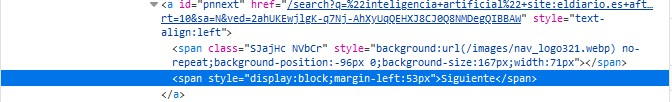

```r
knitr::include_graphics("next_button.jpg")
```

```r
html %>%
  xml_find_all("//a[@id = 'pnnext']/span[2]")
```

```
{xml_nodeset (1)}
[1] <span style="display:block;margin-left:53px">Siguiente</span>
```

```r
remDr$findElement(using = "xpath", value = "//a[@id = 'pnnext']/span[2]")$clickElement()
Sys.sleep(2)
remDr$screenshot(display = T)
```

First I have to read the html and create again the vector with the XPaths of each article:

```r
xpaths
```

```
 [1] "//a[@class = 'WlydOe' and @href='https://www.eldiario.es/euskadi/euskera-vivienda-lanbide-aplica-inteligencia-artificial-gobierno-vasco_1_10078534.html']"
 [2] "//a[@class = 'WlydOe' and @href='https://www.eldiario.es/tecnologia/google-microsoft-ganan-ven-premiada-carrera-inteligencia-artificial_1_10152151.html']"
 [3] "//a[@class = 'WlydOe' and @href='https://www.eldiario.es/euskadi/juan-pablo-villalobos-parece-ingenuo-entusiasmo-genera-inteligencia-artificial_128_10096855.html']"
 [4] "//a[@class = 'WlydOe' and @href='https://cordopolis.eldiario.es/cordoba-hoy/sociedad/expertos-abogan-cordoba-desarrollo-leyes-regulen-revolucion-inteligencia-artificial_1_10117823.html']"
 [5] "//a[@class = 'WlydOe' and @href='https://www.eldiario.es/comunitat-valenciana/medio_ambiente/global-omnium-emplea-inteligencia-artificial-monitorizacion-redes-hidraulicas-optimizar-rendimientos-intervenir-tiempo-real-reducir-huella-carbono_1_10123639.html']"
 [6] "//a[@class = 'WlydOe' and @href='https://www.eldiario.es/opinion/tribuna-abierta/teme-ia-feroz_129_10157901.html']"
 [7] "//a[@class = 'WlydOe' and @href='https://www.eldiario.es/castilla-la-mancha/social/inteligencia-artificial-deteccion-precoz-cancer-mama_1_10125329.html']"
 [8] "//a[@class = 'WlydOe' and @href='https://www.eldiario.es/andalucia/junta-andalucia-pide-gobierno-rectificar-sede-agencia-inteligencia-artificial-persigue-granada_1_10095924.html']"
 [9] "//a[@class = 'WlydOe' and @href='https://www.eldiario.es/castilla-la-mancha/universidades/catedratico-uclm-ve-necesario-castilla-mancha-legisle-inteligencia-artificial_1_10136313.html']"
[10] "//a[@class = 'WlydOe' and @href='https://www.eldiario.es/opinion/zona-critica/ia-gobernarnos_129_10130491.html']"
```

```r
remDr$findElement(using = "xpath", value = "//a[@class = 'WlydOe'][2]")$clickElement()
```

[output not shown]

## Create a dataframe

Now I am going to create a dataframe with the title, the name of the newspaper and the date of the article.

### Find the XPath of the title

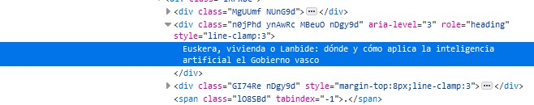

```r
knitr::include_graphics("title.jpg")
```

```r
html %>%
  xml_find_all("//div[@role ='heading' and @style = 'line-clamp:3']") %>%
  xml_text()
```

```
 [1] "Euskera, vivienda o Lanbide: dónde y cómo aplica la inteligencia artificial \nel Gobierno vasco"
 [2] "Google y Microsoft ganan menos pero ven premiada su carrera por la \ninteligencia artificial"
 [3] "Juan Pablo Villalobos: \"Me parece un tanto ingenuo el entusiasmo que genera \nla inteligencia artificial\""
 [4] "Expertos abogan en Córdoba por el desarrollo de leyes que ..."
 [5] "Global Omnium emplea Inteligencia Artificial en la monitorización de redes \nhidráulicas para optimizar rendimientos, intervenir en tiempo real y \nreducir la huella de carbono"
 [6] "¿Quién teme a la IA feroz?"
 [7] "Inteligencia artificial para la detección precoz de cáncer de mama"
 [8] "La Junta de Andalucía pide al Gobierno rectificar la sede de la Agencia de \nInteligencia Artificial que persigue Granada"
 [9] "Un catedrático de la UCLM ve necesario que Castilla-La Mancha legisle sobre \nla inteligencia artificial"
[10] "Una IA para gobernarnos a todos"
```

### Find the XPath of the newspaper name

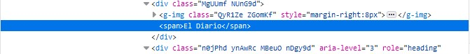

```r
knitr::include_graphics("newspaper_name.jpg")
```

```r
html %>%
  xml_find_all("//div[@class = 'MgUUmf NUnG9d']/span") %>%
  xml_text()
```

```
 [1] "El Diario"  "El Diario"  "El Diario"  "Cordópolis" "El Diario"  "El Diario"
 [7] "El Diario"  "El Diario"  "El Diario"  "El Diario"
```

### Find the XPath of the date

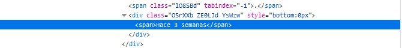

```r
knitr::include_graphics("date.jpg")
```

```r
html %>%
  xml_find_all("//div[@style = 'bottom:0px']//span") %>%
  xml_text()
```

```
 [1] "Hace 3 semanas" "Hace 1 semana"  "Hace 3 semanas" "Hace 3 semanas" "Hace 2 semanas"
 [6] "Hace 5 días"    "Hace 2 semanas" "Hace 1 mes"     "Hace 2 semanas" "Hace 2 semanas"
```

Now that I have find all the XPaths, I need to extract this information for each page in the Google Search and save it in a dataframe.

I need to stop the Docker and then run it again:

```r
remDr <- RSelenium::remoteDriver(remoteServerAddr = "localhost",
                                 port = 4445L,
                                 browserName = "firefox")

remDr$open()
```

[output not shown]

[output cut: 49 more lines]

[output not shown]

```r
remDr$navigate(link_eldiario)
Sys.sleep(2)
remDr$screenshot(display = T)

remDr$findElement(using = "xpath", value = "//button")$clickElement()
Sys.sleep(2)
remDr$screenshot(display = TRUE)
```

```r
title
```

```
 [1] "Intervalo de fechas personalizado"
 [2] "Inteligencia artificial: el miedo a Frankenstein"
 [3] "La inteligencia artificial no solo simula voces, también personalidades: \nasí es el proyecto de los 1.000 millones"
 [4] "Una falsa canción de Drake hecha con inteligencia artificial dispara las \nalarmas en la industria musical"
 [5] "La Inteligencia Artificial se va de Patios"
 [6] "Inteligencia artificial para prever las necesidades de riego en fincas \nagrícolas de Tenerife"
 [7] "Cómo la inteligencia artificial está transformando los ejércitos y la \nnaturaleza de las guerras"
 [8] "Nace CEOE Data, la mayor plataforma de inteligencia artificial al servicio \nde las empresas españolas"
 [9] "La ULPGC impulsa una startup de inteligencia artificial para uso médico"
[10] "\"La porcelana triturada añade calcio a la leche\": el peligro de que la \ninteligencia artificial genere información sanitaria"
[11] "Global Omnium emplea Inteligencia Artificial en la monitorización de redes \nhidráulicas para optimizar rendimientos, intervenir en tiempo real y \nreducir la huella de carbono"
```

Now I have to create a loop to do this for each page of the search:

```r
# Initialize an empty list to store data frames
df_list <- list()

# Initialize the flag variable
continue_loop <- TRUE

# Loop through the pages
while (continue_loop) {

  # Get the page source and read into html
  page_source <- remDr$getPageSource()[[1]]
  html <- read_html(page_source)

  # Scrape the data
  title <- html %>%
    xml_find_all("//div[@role ='heading' and @aria-level = '3']") %>%
    xml_text()

  newspaper <- html %>%
    xml_find_all("//div[@class = 'CEMjEf NUnG9d']/span") %>%
    xml_text()

  date <- html %>%
    xml_find_all("//div[@style = 'bottom:0px']//span") %>%
    xml_text()

  link <- html %>%
  xml_find_all("//a[@class = 'WlydOe']") %>%
  xml_attr("href")


  # Save the vectors in a data frame
  df <- data.frame(title, newspaper, date, link)

  # Add the data frame to the list
  df_list[[length(df_list) + 1]] <- df

  # Attempt to click the "next page" button
  tryCatch({
    remDr$findElement(using = "xpath", "//a[@id = 'pnnext']/span[2]")$clickElement()
  }, error = function(e) {
    continue_loop <<- FALSE  # Set the flag variable to exit the loop
  })

  remDr$screenshot(display = T)

  # Wait for the page to load
  Sys.sleep(3)
}

# Combine all data frames in the list into one
final_df <- do.call(rbind, df_list)
```

```r
remDr$close()
```

## Dataframe with the content of the articles

Now to do text analysis I need to extract the content of each article. To do this I need to create a loop which first navigate into the original link (*link_eldiario* and *link_elmundo*), and then navigate to each news item and extract the text of the news item. In addition, as in the previous loop it will be necessary that once the information is extracted from the first page of the search the remote browser switches to the next one and repeats the process, and so on until the last one is reached.

### Find the XPath of the article text

#### elDiario.es

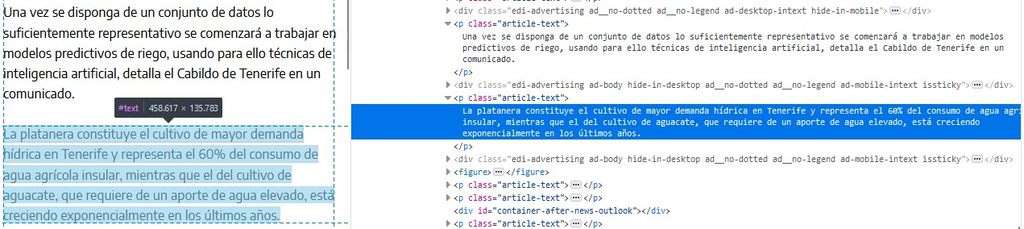

```r
knitr::include_graphics("article_text.jpg")
```

**Click on the first article and read the html**

```r
remDr$findElement("xpath", "//a[@class = 'WlydOe']")$clickElement()
```

**Find the XPath**

```r
text
```

```
[1] "\n        El Instituto Tecnológico y de Energías Renovables (ITER), el Instituto Canario de Investigaciones Agrarias (ICIA) y la Universidad de La Laguna colaboran en un proyecto que plantea la aplicación de la inteligencia artificial para predecir las necesidades de riego en fincas agrícolas.\…
```

**Find the button to accept cookies in eldiario.es**

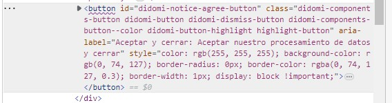

```r
knitr::include_graphics("cookies_eldiario.jpg")
```

**Create the loop**

I need to stop the Docker and then run it again:

```r
remDr <- RSelenium::remoteDriver(remoteServerAddr = "localhost",
                                 port = 4445L,
                                 browserName = "firefox")

remDr$open()
```

[output not shown]

[output cut: 49 more lines]

[output not shown]

```r
remDr$navigate(link_eldiario)
Sys.sleep(2)
#remDr$screenshot(display = T)

remDr$findElement(using = "xpath", value = "//button")$clickElement()
Sys.sleep(2)
remDr$screenshot(display = TRUE)
```

```r
eldiario_df <- data.frame(text = character())

page_source <- remDr$getPageSource()[[1]]
Sys.sleep(2)
html <- read_html(page_source)
Sys.sleep(2)

# List with the links of each article
hrefs <- html %>%
  xml_find_all("//a[@class = 'WlydOe']") %>%
  xml_attr("href")

# Create a vector with each XPath
xpaths <- paste0("//a[@class = 'WlydOe' and @href='", hrefs, "']")

# Accept cookies
remDr$findElement(using = "xpath", value = xpaths[1])$clickElement()
Sys.sleep(2)

remDr$findElement(using = "xpath", value = "//button[@id =
                    'didomi-notice-agree-button']")$clickElement()
Sys.sleep(2)
remDr$goBack()
Sys.sleep(2)

remDr$screenshot(display = T)
```

```r
# Click on each xpath

for (xpath in xpaths) {

  remDr$findElement(using = "xpath", value = xpath)$clickElement()
  # Sys.sleep(5)
  #remDr$screenshot(display = T)

  # Extract the text
  page_source <- remDr$getPageSource()[[1]]
  # Sys.sleep(5)
  html <- read_html(page_source)

  text <- html %>%
  xml_find_all("//p[@class = 'article-text']") %>%
  xml_text()

  text <- paste(text, collapse = "")
  eldiario_df <- rbind(eldiario_df, data.frame(text = text))
  gc()

  # Sys.sleep(5)
  remDr$goBack()

  # Sys.sleep(5)
  # remDr$screenshot(display = T)

}
```

```
Error in checkError(res) :
  Undefined error in httr call. httr output: Operation was aborted by an application callback
```